# EDA Danych dotyczących Irysów

## O Danych

Zbiór danych zawiera informacje o trzech gatunkach irysów: Iris setosa, Iris versicolor, i Iris virginica.

Dane obejmują pomiary czterech cech: długość i szerokość działki kielicha oraz długość i szerokość płatka.

Każdy wiersz w zbiorze danych reprezentuje pojedynczy kwiat, a wartości pomiarów są podane w centymetrach.

Zbiór składa się z 150 próbek, po 50 dla każdego gatunku, i jest szeroko stosowany jako podstawowy zbiór danych do testowania algorytmów klasyfikacji oraz w nauce o danych i uczeniu maszynowym.

Kolumny:

- **długość kielicha (sepal length)** - Długość kielicha w cm
- **szerokość kielicha (sepal width)** - Szerokość kielicha w cm
- **długość płatka (petal length)** - Długość płatka w cm
- **szerokość płatka (petal width)** - Szerokość płatka w cm
- **klasa (class)** - Klasa irysa (setosa, versicolor, virginica)

# Ogólny przeglad danych

|  | długość kielicha (sepal length) | szerokość kielicha (sepal width) | długość płatka (petal length) | szerokość płatka (petal width) | klasa (class) |
| --- | --- | --- | --- | --- | --- |
| 132 | 6.4 | 2.8 | 5.6 | 2.2 | Iris-virginica |
| 39 | 5.1 | 3.4 | 1.5 | 0.2 | Iris-setosa |
| 133 | 6.3 | 2.8 | 5.1 | 1.5 | Iris-virginica |
| 36 | 5.5 | 3.5 | 1.3 | 0.2 | Iris-setosa |
| 60 | 5.0 | 2.0 | 3.5 | 1.0 | Iris-versicolor |

## Wartości unikatowe

```
array(['Iris-setosa', 'Iris-versicolor', 'Iris-virginica'], dtype=object)
```

# Analiza danych brakujacych i duplikatów

```
długość kielicha (sepal length)     0
szerokość kielicha (sepal width)    0
długość płatka (petal length)       0
szerokość płatka (petal width)      0
klasa (class)                       0
dtype: int64
```

### Suma dupliakatów

```
3
```

# Eksploracja danych z wykresami

## średnie wartości dla elementów kwiatów

|  | klasa (class) | długość kielicha (sepal length) mean | długość kielicha (sepal length) std | szerokość kielicha (sepal width) mean | szerokość kielicha (sepal width) std | długość płatka (petal length) mean | długość płatka (petal length) std | szerokość płatka (petal width) mean | szerokość płatka (petal width) std |
| --- | --- | --- | --- | --- | --- | --- | --- | --- | --- |
| 0 | Iris-setosa | 5.006 | 0.352490 | 3.418 | 0.381024 | 1.464 | 0.173511 | 0.244 | 0.107210 |
| 1 | Iris-versicolor | 5.936 | 0.516171 | 2.770 | 0.313798 | 4.260 | 0.469911 | 1.326 | 0.197753 |
| 2 | Iris-virginica | 6.588 | 0.635880 | 2.974 | 0.322497 | 5.552 | 0.551895 | 2.026 | 0.274650 |

## średnie wartości dla elementów kwiatów wykres

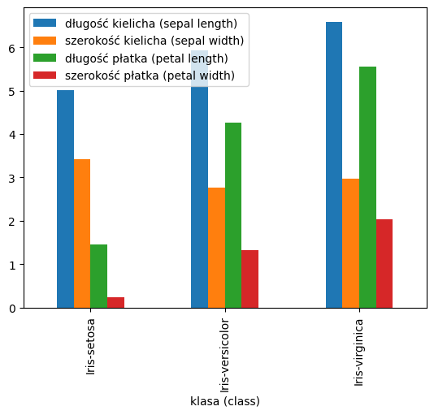

## Obliczenie pola powierzchni płatków kwiatów w grupach klas

|  | klasa (class) | mean | std |
| --- | --- | --- | --- |
| 0 | Iris-setosa | 0.3628 | 0.183248 |
| 1 | Iris-versicolor | 5.7204 | 1.368403 |
| 2 | Iris-virginica | 11.2962 | 2.157412 |

### Wykres przedstawiajacy różnice w średnich długości kielicha w podziale na klasy

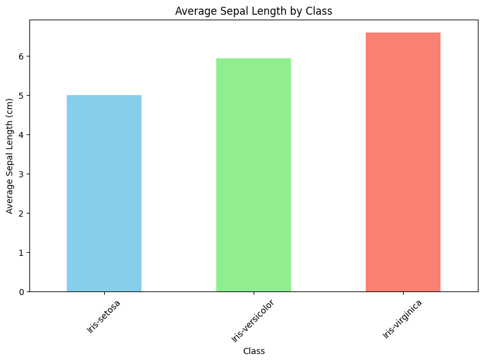

# Analiza korelacji

### wynik korelacji

```
0.8717541573048712
```

## Wykres korelacji

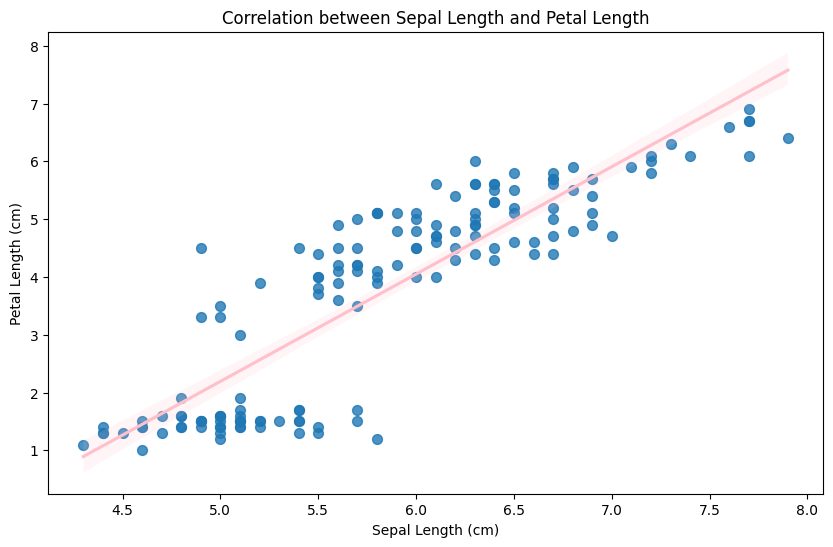

## Analiza danych odstajacych

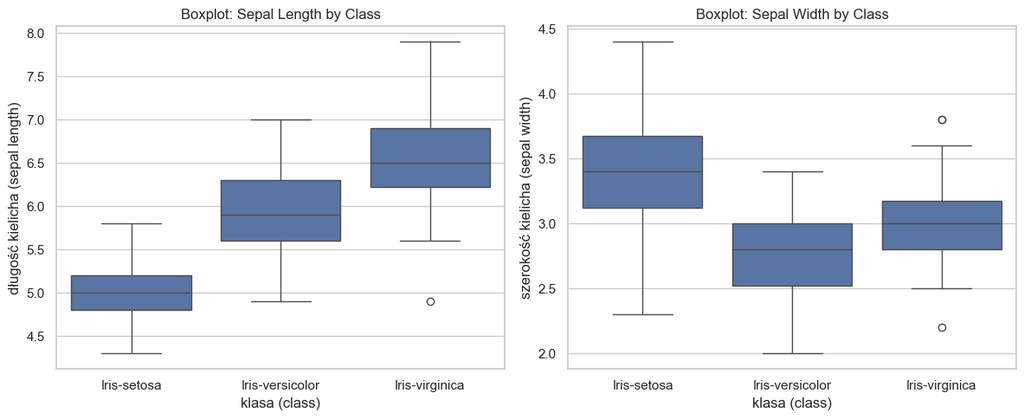

## Analiza danych odstających – ciąg dalszy

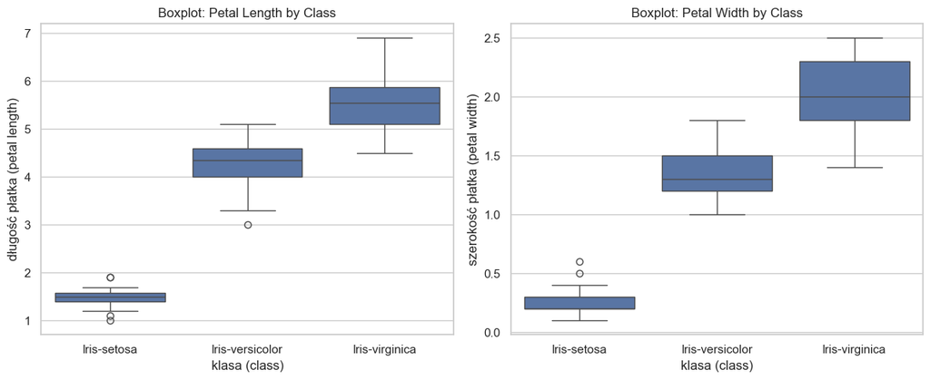

# Wnioski analizy

##### Baza danych była kompletna, nie zawierała braków, a wykryte 3 duplikaty prawdopodobnie wynikają z powtórzeń pomiarowych i nie miały istotnego wpływu na dalszą analizę.

##### Aby porównać rozmiary kwiatów między klasami, obliczono pole powierzchni płatków (petal_area). Największą średnią powierzchnię miał Iris-virginica (11.30 cm², SD = 2.16), natomiast najmniejszą Iris-setosa (0.36 cm², SD = 0.18). Podobny trend zaobserwowano w długości kielicha, najdłuższe miał Iris-virginica (6.59 cm, SD = 0.64).

##### Analiza korelacji wykazała silne zależności między zmiennymi: między długością kielicha a długością płatka (r = 0.87), między szerokością a długością płatka (r = 0.96) oraz długością kielicha a szerokością płatka (r = 0.82).

##### Boxplot ujawniły obecność wartości odstających, głównie w grupie Iris-setosa, w zmiennych opisujących płatki. Może to wskazywać na większą zmienność wewnątrz tej klasy lub obecność pojedynczych, nietypowych okazów.

##### Podsumowując, dane okazały się kompletne i nie wymagały większego czyszczenia. Analiza pokazała wyraźne różnice między gatunkami kwiatów, zwłaszcza jeśli chodzi o długość i szerokość płatków. Niektóre cechy były ze sobą mocno powiązane, co może być przydatne przy budowaniu modelu. W kolejnym kroku warto spróbować stworzyć model klasyfikacyjny, który rozpozna gatunek na podstawie tych cech, gdzie szczególnie pomocne mogą być cechy płatków.